# Lecture 25 R Demo – So Much More

Sam Ventura

November 30, 2016

# `R` Notebooks

This is one of the reasons why we updated `R` and RStudio this week. `R` Notebooks are similar to Jupyter notebooks (Python).

See here for more details: [https://blog.rstudio.org/2016/10/05/r-notebooks/]

I HIGHLY encourage you to read the info at the above link. There’s a lot of really cool stuff you can do with these.

## Python

Speaking of Python: Did you know you can use `R` Markdown to run code in other languages?

```python
def fib(n):
  a, b = 0, 1
  for _ in xrange(n):
    yield a
    a, b = b, a + b
print(list(fib(11)))
```

```
## [0, 1, 1, 2, 3, 5, 8, 13, 21, 34, 55]
```

## SQL

You can also run SQL queries within your `R` Notebook:

(Note: I’m not adding the `` `'s here, because I don't actually have a ``SQL`database called`db`or`my_database`)

{SQL, connection = db} SELECT * FROM my_database

## bash

You can run bash scripts as well:

```bash
cd /Users/sam/Desktop/bike/
ls
```

```
## 2013-07 - Citi Bike trip data.csv
## 2013-08 - Citi Bike trip data.csv
## 2013-09 - Citi Bike trip data.csv
## 2013-10 - Citi Bike trip data.csv
## 2013-11 - Citi Bike trip data.csv
## 2013-12 - Citi Bike trip data.csv
## 2014-01 - Citi Bike trip data.csv
## 2014-02 - Citi Bike trip data.csv
## 2014-03 - Citi Bike trip data.csv
## 2014-04 - Citi Bike trip data.csv
## 2014-05 - Citi Bike trip data.csv
## 2014-06 - Citi Bike trip data.csv
## 2014-07 - Citi Bike trip data.csv
## 2014-08 - Citi Bike trip data.csv
## 201409-citibike-tripdata.csv
## 201410-citibike-tripdata.csv
## 201411-citibike-tripdata.csv
## 201412-citibike-tripdata.csv
## 201501-citibike-tripdata.csv
## 201502-citibike-tripdata.csv
## 201503-citibike-tripdata.csv
## 201504-citibike-tripdata.csv
## 201505-citibike-tripdata.csv
## 201506-citibike-tripdata.csv
## 201507-citibike-tripdata.csv
## 201508-citibike-tripdata.csv
## 201509-citibike-tripdata.csv
## 201510-citibike-tripdata.csv
## 201511-citibike-tripdata.csv
## 201512-citibike-tripdata.csv
## 201601-citibike-tripdata.csv
## 201602-citibike-tripdata.csv
## 201603-citibike-tripdata.csv
## 201604-citibike-tripdata.csv
## 201605-citibike-tripdata.csv
## 201606-citibike-tripdata.csv
## 201607-citibike-tripdata.csv
## 201608-citibike-tripdata.csv
## 201609-citibike-tripdata.csv
```

## PDF Documents

For those of you who like LaTeX, you can use RMarkdown to generate PDF documents in addition to HTML documents. Just change:

`output: html_document` to `output: pdf_document`

Be careful though, because you need to have the appropriate LaTeX tools installed on your computer. RMarkdown with HTML, on the other hand, will work on any computer.

# `ggplot2` Extras

A new version of `ggplot2` was just released. Here’s a quick overview of some of the interesting features.

See here for more information:

- [https://blog.rstudio.org/2016/11/14/ggplot2-2-2-0/]
- [https://www.r-bloggers.com/announcing-ggforce-accelerating-ggplot2]

## Subtitles and Captions

We can now add subtitles and captions to graphs.

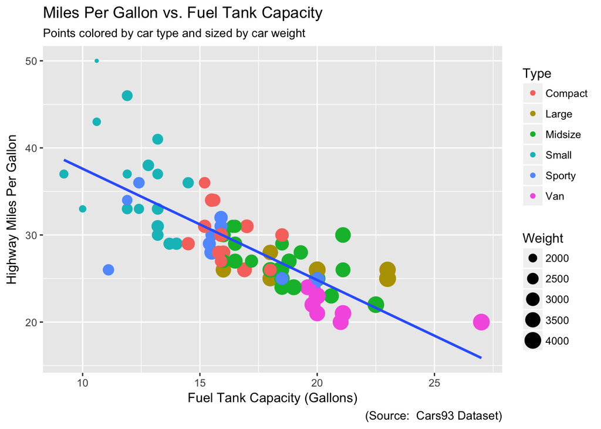

```r
library(ggplot2)
library(MASS)
data(Cars93)

ggplot(Cars93, aes(x = Fuel.tank.capacity, y = MPG.highway)) +
  geom_point(aes(color = Type, size = Weight)) +
  geom_smooth(se = F, method = "lm") +
  labs(
    title = "Miles Per Gallon vs. Fuel Tank Capacity",
    subtitle = "Points colored by car type and sized by car weight",
    caption = "(Source:  Cars93 Dataset)",
    x = "Fuel Tank Capacity (Gallons)",
    y = "Highway Miles Per Gallon"
  )
```

## Hexagonal Bin Plots

These can be used as an alternative to traditional density estimation via contour plots or heat maps.

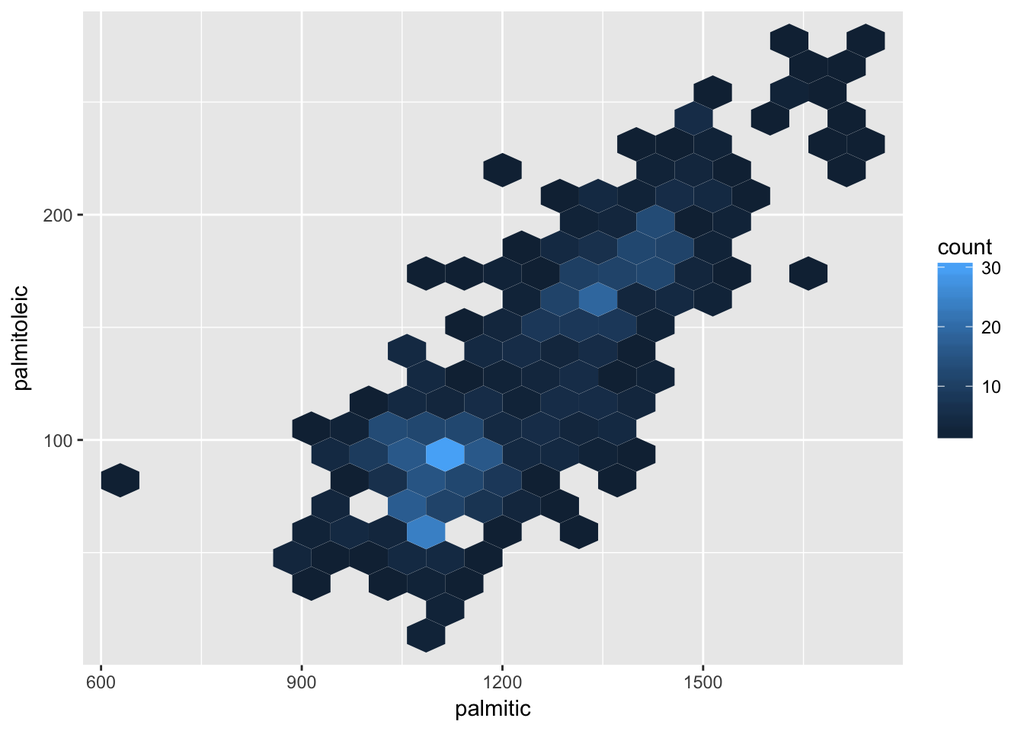

```r
#install.packages("hexbin")
library(tidyverse)
olive <- read_csv("https://raw.githubusercontent.com/sventura/315-code-and-datasets/master/data/olive_oil.csv")
ggplot(olive, aes(x = palmitic, y = palmitoleic)) +
  geom_hex(bins = 20)
```

## `ggforce` Package and `facet_zoom()`

`facet_zoom()` allows you to zoom in on specific parts of the plot.

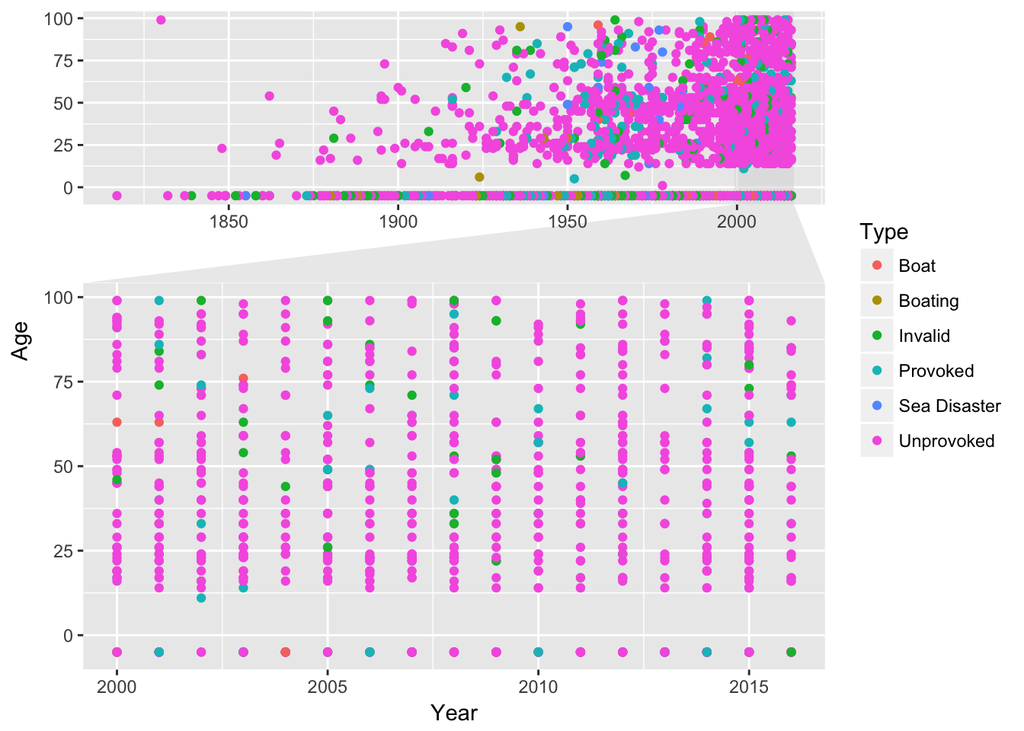

```r
#install.pacakges("ggforce")
library(ggforce)
shark <- read_csv("https://raw.githubusercontent.com/sventura/315-code-and-datasets/master/data/attacks_test.csv")

ggplot(shark, aes(y = Age, x = Year)) +
  geom_point(aes(color = Type)) +
  facet_zoom(x = Year %in% 2000:2016)
```

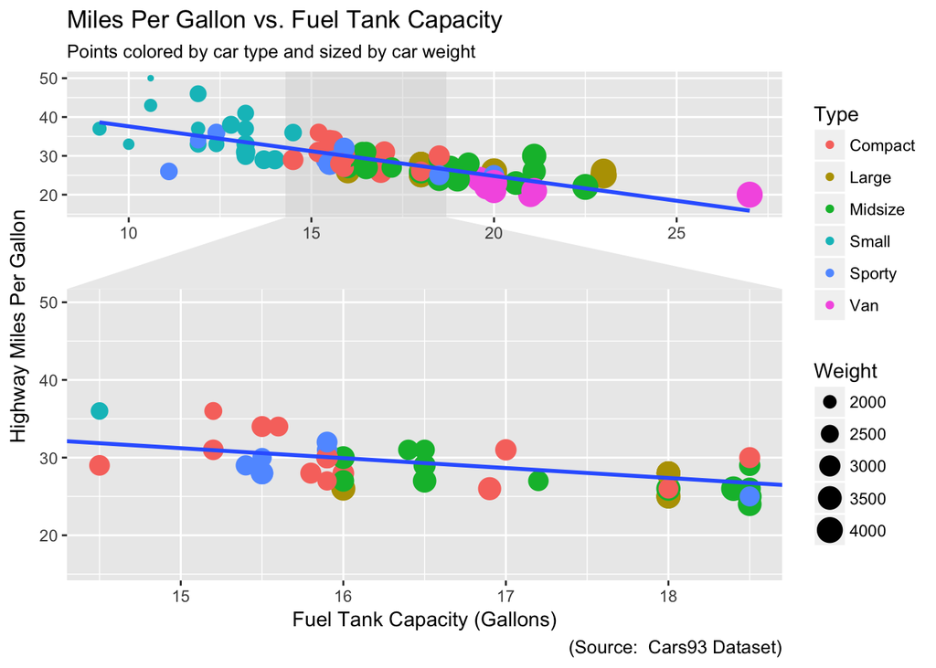

```r
ggplot(Cars93, aes(x = Fuel.tank.capacity, y = MPG.highway)) +
  geom_point(aes(color = Type, size = Weight)) +
  geom_smooth(se = F, method = "lm") +
  labs(
    title = "Miles Per Gallon vs. Fuel Tank Capacity",
    subtitle = "Points colored by car type and sized by car weight",
    caption = "(Source:  Cars93 Dataset)",
    x = "Fuel Tank Capacity (Gallons)",
    y = "Highway Miles Per Gallon"
  ) + facet_zoom(x = Type == "Compact")
```

# Interactive Graphics Packages

## Flex Dashboard

Flex Dashboard is a really nice way to integrate your RMarkdown konwledge with Shiny. It creates great-looking dashboard-style outupt that can be used when creating interactive graphics.

I’m going to demo how to create a flex dashboard, and then show a few examples.

Here are some links on the `flexdashboard` package:

- [https://blog.rstudio.org/2016/05/17/flexdashboard-easy-interactive-dashboards-for-r/]
- [http://rmarkdown.rstudio.com/flexdashboard/]
- [http://rmarkdown.rstudio.com/flexdashboard/examples.html]

## Shiny Themes

A closely related concept to `flexdashboard` is “Shiny Themes” (`shinythemes`), which allow you to choose different themes for your Shiny apps.

Here are some links on the `shinythemes` package:

- [https://blog.rstudio.org/2016/10/13/shinythemes-1-1-1/]
- [https://rstudio.github.io/shinythemes/]

## Plotly

Plotly is **the best** package to make interactive graphics in `R` both within and outside of `shiny`. It uses D3.js on the backend, so there’s a lot of syntax that you may be unfamiliar with when comparing to `ggplot2` and some of the other `R` packages we’ve used this year. Luckily, there’s a free online book with a TON of example code (see links below) that should make it fairly easy to integrate into your final project.

You can easily use the `ggplotly()` function to create interactive versions of static graphics that have some features automatically included (e.g. alt-text).

You can also use the `plot_ly()` function to create new interactive graphs.

First, some links:

- This is a comprehensive look into what you can do with Plotly in the form of a (free) book, including a ton of example code: [https://cpsievert.github.io/plotly_book/index.html]
- Here’s the GitHub page for `plotly`, including a vignette with many examples: [https://github.com/ropensci/plotly]

One nice feature of `plotly` is “linked brushing”, which is often also referred to as “ribbons” or “linked views” or “multiple views” or “polygons”. I’ll do a demo of this from the book above, and another demo using data from the [2016 Presidential Election](http://rpubs.com/cpsievert/229092).

## HTML Widgets

HTML Widgets are a superset of `plotly`. They are in-development additions to the ever-growing list of possibily ways to make awesome charts in `R`.

Because these are being developed, updated, and improved, I don’t know how to use all of these. By the end of your final project, you will certainly know more about some of these topics than I will.

Some links:

- HTML Widgets Showcase: [http://www.htmlwidgets.org/showcase_metricsgraphics.html]
- HTML Widgets Gallery: [http://gallery.htmlwidgets.org/]

## Custom JavaScript Widgets in Shiny

Create custom JavaScript widgets for Shiny! Watch the tutorials described here: [https://blog.rstudio.org/2016/05/06/shiny-javascript-tutorials/]

## Miscellaneous

- Here’s a post about how you can use the `ggiraph` pacakge to make interactive graphics relating to the 2016 Olympics: [http://blog.revolutionanalytics.com/2016/08/interactive-illustrator-quality-graphics-with-r.html]
- Here’s more info on that package: [https://mran.microsoft.com/package/ggiraph/]
- Here’s the code for that analysis: [https://github.com/d-qn/2016_08_02_rioOlympicsAthletes]